# hw4_nguyen

Nguyen

3/1/2022

```r
df <- read.csv("https://ds202-at-isu.github.io/labs/data/choco.csv")
summary(df)
```

```
##    Company          Specific.Bean.Origin      REF        Review.Date
##  Length:1852        Length:1852          Min.   :   5   Min.   :2006
##  Class :character   Class :character     1st Qu.: 600   1st Qu.:2010
##  Mode  :character   Mode  :character     Median :1099   Median :2013
##                                          Mean   :1065   Mean   :2012
##                                          3rd Qu.:1546   3rd Qu.:2015
##                                          Max.   :2008   Max.   :2017
##    Cocoa.Pct     Company.Location       Rating       Bean.Type
##  Min.   : 42.0   Length:1852        Min.   :1.000   Length:1852
##  1st Qu.: 70.0   Class :character   1st Qu.:3.000   Class :character
##  Median : 70.0   Mode  :character   Median :3.250   Mode  :character
##  Mean   : 71.7                      Mean   :3.191
##  3rd Qu.: 75.0                      3rd Qu.:3.500
##  Max.   :100.0                      Max.   :5.000
##  Broad.Bean.Origin
##  Length:1852
##  Class :character
##  Mode  :character
##
##
##
```

> **Question set 1**: 1. What is the overall number of chocolate bars rated?

Answer: From the summary, there are 1852 rows means there are 1852 chocolate bars were rated.

> 2. How does the number of ratings depend on the year? Draw a bar chart of the number of reports.

Answer: The number of ratings tend to increase from 2006 to 2015 and observable decrease after 2015. In 2017, the number of ratings was as low as in 2007.

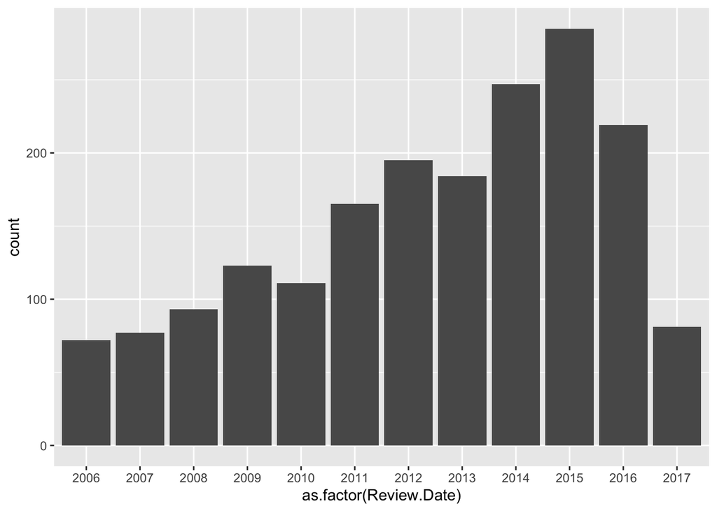

```r
df %>% ggplot(aes(x= as.factor(Review.Date))) +geom_bar()
```

> **Question set 2**: 1. How are ratings distributed? Draw a histogram of ratings and describe it. Don’t forget to mention outliers, if there are any.

```r
#Summary statistic of rating
summary(df$Rating)
```

```
##    Min. 1st Qu.  Median    Mean 3rd Qu.    Max.
##   1.000   3.000   3.250   3.191   3.500   5.000
```

Answer: I’m using the mean and standard deviation of rating by year to show Ratings’ distribution. As we can see from the table below, 2017 has the highest average rating of 3.34, on the other hand, 2008 has the lowest rating of 2.99.

```r
#mean of rating adn sd of rating
df %>% summarise(averageRating = mean(Rating),sdRating = sd(Rating))
```

```
##   averageRating  sdRating
## 1       3.19101 0.4754893
```

```r
df %>% group_by(Review.Date) %>% summarise(averageRating = mean(Rating), sdRating = sd(Rating))
```

```
## # A tibble: 12 × 3
##    Review.Date averageRating sdRating
##          <int>         <dbl>    <dbl>
##  1        2006          3.12    0.769
##  2        2007          3.16    0.700
##  3        2008          2.99    0.544
##  4        2009          3.07    0.459
##  5        2010          3.15    0.466
##  6        2011          3.26    0.490
##  7        2012          3.18    0.484
##  8        2013          3.20    0.446
##  9        2014          3.19    0.415
## 10        2015          3.25    0.381
## 11        2016          3.23    0.421
## 12        2017          3.34    0.345
```

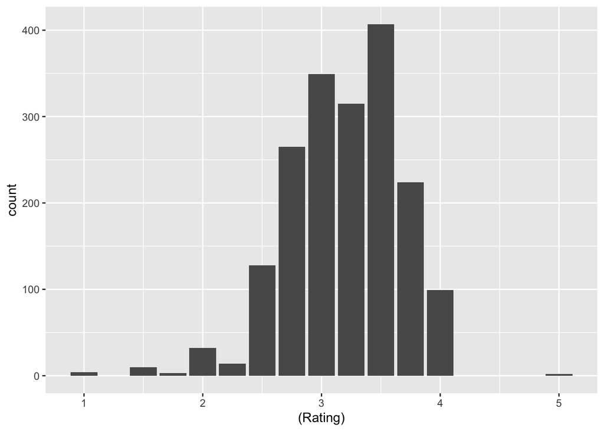

```r
df %>% ggplot(aes(x= (Rating))) +geom_bar()
```

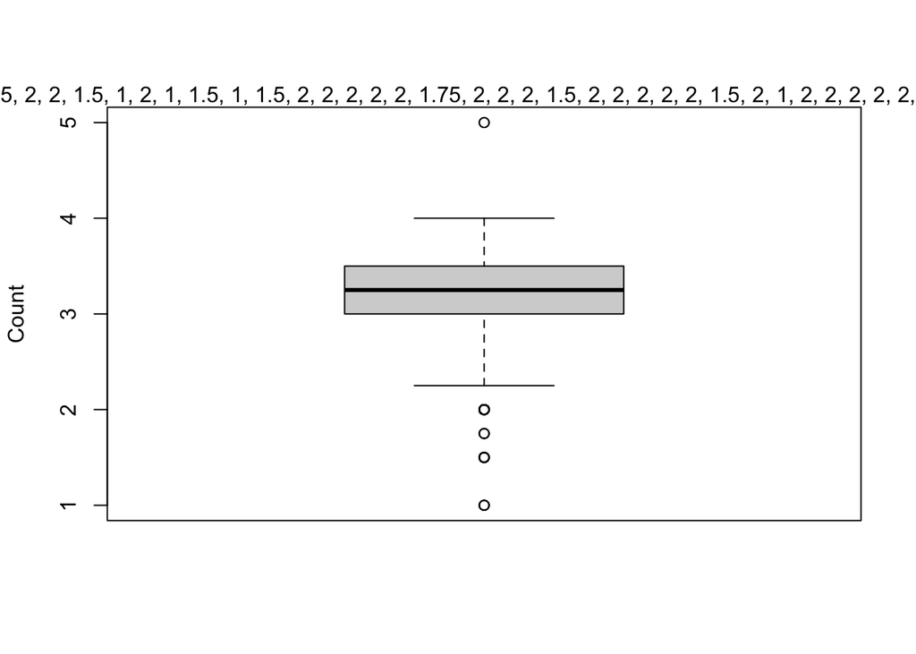

```r
#Detect outliers with boxplot
# I use the mtext function to print out the outliers
out <- boxplot.stats(df$Rating)$out
boxplot(df$Rating,
  ylab = "Count"
)
mtext(paste("Outliers: ", paste(out, collapse = ", ")))
```

> 2. Do ratings depend on the cocoa percentage of a chocolate bar?

Answer: Most chocolate bars appear to have a cocoa percentage ranging between 70% and 80%. The average cocoa content is 71.7 percent, with values ranging from 42 percent to 100 percent. We can easily observe that the majority of the passable to commendable chocolate bars included 70-79 percent cacao. Some bars with a greater cacao percentage fell into the unpleasant and unsatisfactory categories ( shows via rating). In short, we can tell ratings somehow depend on the cocoa percentage of a chocolate bar.

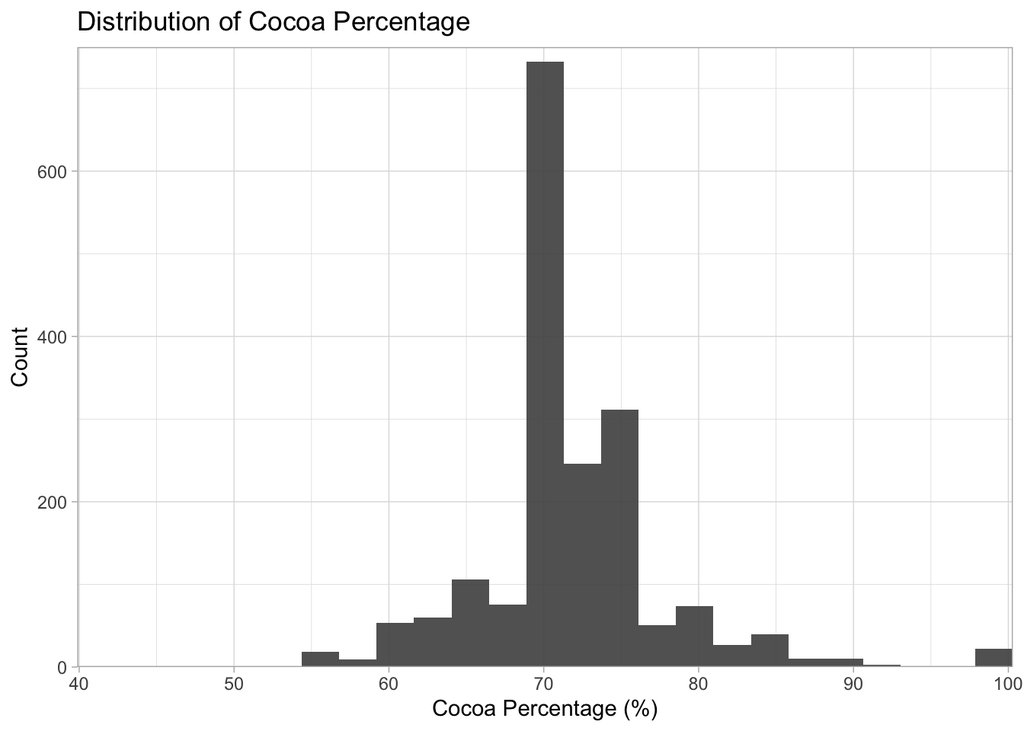

```r
# Histogram of Cocoa Content
ggplot(data = df, aes(x = Cocoa.Pct)) +
  geom_histogram(bins = 25, alpha = 0.95) + # set number of bins to 20
  theme_light() + # Use a custome theme
  coord_cartesian(expand = FALSE, ylim = c(0, 750)) +
  labs(x = "Cocoa Percentage (%)",
       y = "Count",
       title = "Distribution of Cocoa Percentage")
```

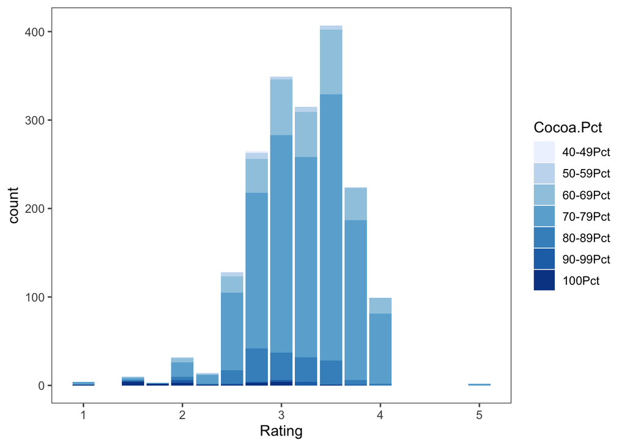

```r
options(repr.plot.width=5, repr.plot.height=7)
df <- mutate(df, Cocoa.Pct)
df$Cocoa.Pct[df$Cocoa.Pct >=40 & df$Cocoa.Pct < 50] <- '40-49Pct'
df$Cocoa.Pct[df$Cocoa.Pct >=50 & df$Cocoa.Pct < 60] <- '50-59Pct'
df$Cocoa.Pct[df$Cocoa.Pct >=60 & df$Cocoa.Pct < 70] <- '60-69Pct'
df$Cocoa.Pct[df$Cocoa.Pct >=70 & df$Cocoa.Pct < 80] <- '70-79Pct'
df$Cocoa.Pct[df$Cocoa.Pct >=80 & df$Cocoa.Pct < 90] <- '80-89Pct'
df$Cocoa.Pct[df$Cocoa.Pct >=90 & df$Cocoa.Pct <= 99] <- '90-99Pct'
df$Cocoa.Pct[df$Cocoa.Pct== 100] <- '100Pct'

df$Cocoa.Pct <- factor(df$Cocoa.Pct, levels = c("40-49Pct", "50-59Pct", "60-69Pct","70-79Pct", "80-89Pct", "90-99Pct","100Pct"))

ggplot(df ,aes(x =Rating, fill =Cocoa.Pct )) +
geom_bar(size = 0.2) + xlab("Rating") + scale_fill_brewer(palette="Blues")+
theme_few()
```

> 3. How do ratings compare across different company locations? Focus on the three locations with the most ratings:

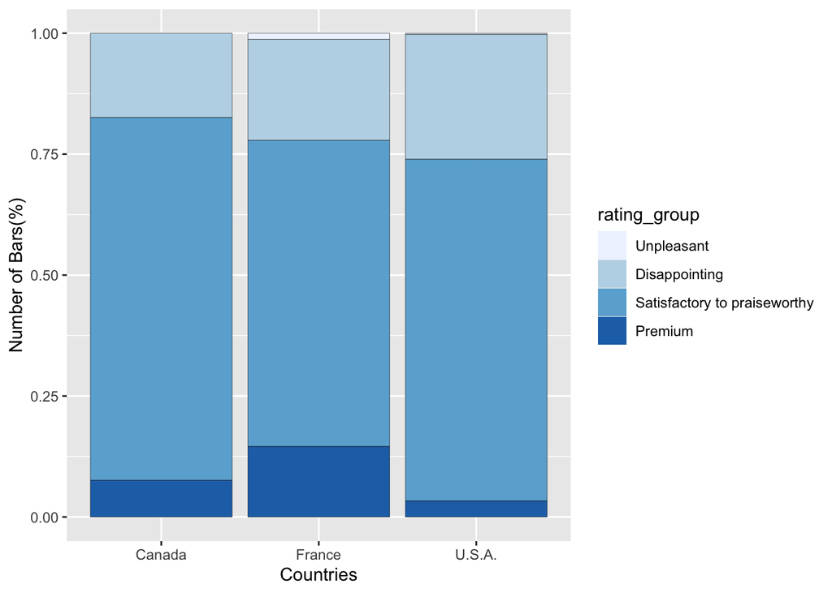

```r
# filter 3 top 3 countries
top3 <- dplyr::filter(df, Company.Location %in% c("U.S.A.", "France", "Canada"))

# grading set up
# Instead of use the rating's values, I will group them into 5 groups.
top3 <- mutate(top3, rating_group = Rating)

top3$rating_group[top3$rating_group >=1 & top3$rating_group < 2] <- "Unpleasant"
top3$rating_group[top3$rating_group >=2 & top3$rating_group < 3] <- "Disappointing"
top3$rating_group[top3$rating_group >=3 & top3$rating_group <= 3.75] <- "Satisfactory to praiseworthy"

top3$rating_group[top3$rating_group == 4] <- "Premium"
top3$rating_group[top3$rating_group == 5] <- "Elite"
top3$rating_group <- factor(top3$rating_group, levels = c("Unpleasant", "Disappointing", "Satisfactory to praiseworthy","Premium", "Elite"))

# graph to show rating compare arcoss USA, France and Canada
options(repr.plot.width=10, repr.plot.height=10)
top3$rating_group = factor(top3$rating_group,levels=c("Unpleasant", "Disappointing", "Satisfactory to praiseworthy","Premium", "Elite"),ordered=TRUE)
top3 %>% group_by(Company.Location, rating_group) %>% summarise(Count = length(rating_group))%>%
ggplot(aes(x =Company.Location, y =Count, fill = rating_group)) +
geom_bar(position = 'fill',stat = "identity", aes(color = I('black')), size = 0.1) +scale_fill_brewer(palette="Blues")+ xlab("Countries") + ylab("Number of Bars(%)")
```

> **Own Question**: What’s the most popular bean type?

Answer: There is one kind of bean the chocolate bar has close to 50% is unknown. The 2nd place is the Trinitario (20%)

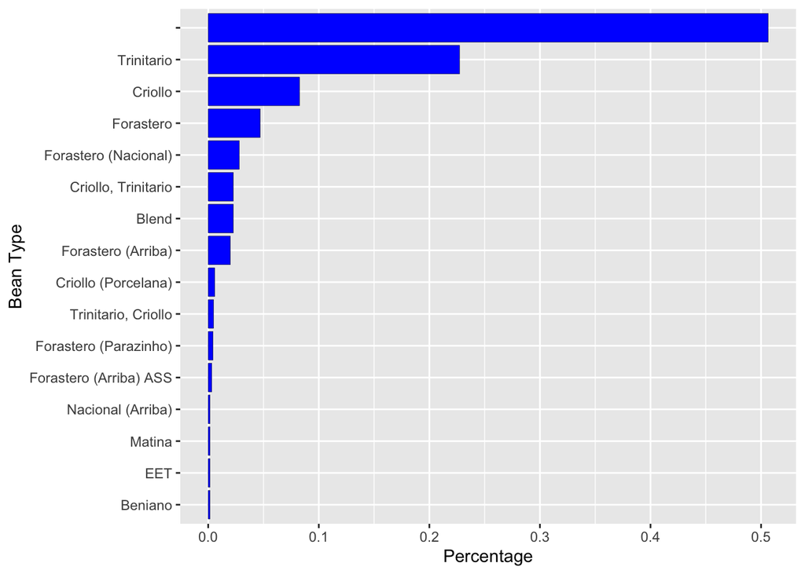

```r
df %>% group_by(Bean.Type) %>% summarise(Count= n())%>% mutate(pct=Count/sum(Count)) %>% top_n(15, wt = pct)%>%
ggplot(aes(x =reorder(Bean.Type,pct), y =pct, fill = pct)) + geom_bar(stat = "identity", fill = "blue", aes(color = I('black')), size = 0.1) + coord_flip()+ xlab("Bean Type") +ylab("Percentage")
```

- Workflow: I group the bean type together using pipe. Then calculate the pct (percentage) by number of count divided by sum of total count. Then use the ggplot2 to display the result.